# Python_Practices

### Python Practices

#### 1. Simple Math and Print

```python
a = 2
b = 3.
c = b/a
print(c)
```

#### 2. String: Split and Joint, Count

```python
text = "The quick brown fox jumped over the lazy log."
mytext = text.split()
print(mytext)
print(" ".join(mytext))
print(text.find("fox"))

count = 0
for x in mytext:
    if "e" in x:
        count += 1

print("'e' is repeated",count, "times")
```

#### 3. User Input as Integer

The user input is taken as "b" and compared to the variable "a".

```python
a = 5
b = int(input("Give me a number:"))
if b == a:
    print("Yes, right")
else:
    print("No, No..!")
```

#### 4. Open and Read Files

First create a file named "ques.txt" and enter some questions in it. Read the file then in your Python code. Consider that it is an interview and you need to register the time as well. Ask the person name first and then save the file under his name.

```python
import datetime
file = open('ques.txt', 'r')
username = input("What is your name? ")
myfile = open(username+".txt", "a")
myfile.close()
output = open(username+".txt", "r+")
for line in file:
    the_reply = input(line)
    line1= line+"{0}: {1} \n".format(username, the_reply)
    output.write(line1)

output.write("\n")
output.write("Interview Time: "+str(datetime.datetime.now().time()))
output.close()
```

#### 5. Read a File

Read the file that you created line by line with answers from the interviewee.

```python
file = open("User.txt", "r")
mylines = file.readlines()

for line in mylines:
    my_next = mylines.index(line)+1
    if "How old are you?" in line:
        print(mylines[my_next])
    if "What is your job?" in line:
        print(mylines[my_next])
    if "Where are you from?" in line:
        print(mylines[my_next])
```

#### 6. Adding Answers to Dictionary

Create an empty dictionary and add the questions and answers to it.

```python
file = open("User.txt", "r")
mylines = file.readlines()
mydict = {}
for line in mylines:
    my_next = mylines.index(line)+1
    if "How old are you?" in line:
        mydict[mylines[my_next]]=mylines.index(line)
    if "What is your job?" in line:
        mydict[mylines[my_next]]=mylines.index(line)
    if "Where are you from?" in line:
        mydict[mylines[my_next]]=mylines.index(line)

print(mydict)
```

#### 7. Sort the Dictionary

To know how to sort the dict.

```python
file = open("User.txt", "r")
mylines = file.readlines()

mydict = {}
for line in mylines:
    my_line = line.replace("\n", "")
    mydict[my_line]=mylines.index(line)


print(sorted(mydict.items(), key=lambda x: x[1]))
```

#### 8. How to Run a Flask Webserver

A very simple web page with Flask which resolves in port 5000. Name the file "hello.py" and then run it with following commands: $ export FLASK_APP=hello.py $ flask run (public access: flask run --host=0.0.0.0) Quick start can be found here: http://flask.pocoo.org/docs/0.12/quickstart/

```python
from flask import Flask
from flask import request

app = Flask(__name__)

@app.route('/')
def index():
    return 'Welcome'

@app.route('/login')
def login():
    username = request.args.get('username')
    password = request.args.get('password')
    return '%s is' %username

@app.route('/user/<username>')
def show_user_profile(username):
    # show the user profile for that user
    return '<html><body>This is a tes to see if <span style="font-weight:bold">%s</span> is shown in middle of html text</body></html>' % username

@app.route('/post/<int:post_id>')
def show_post(post_id):
    # show the post with the given id, the id is an integer
    return 'Post %d' % post_id

@app.route('/test')
def test():
    return 'this is a test'


if __name__ == '__main__':
    app.run(host='127.0.0.1', port=5000)
```

#### 9. Command Line Arguments

To run the code, type in the command line:

$ python test.py arg1 arg2 arg3

in which arguments can be for example "user1.txt" "user2.txt", etc

```python
#!/usr/bin/python
import sys

# Get the total number of args passed to the demo.py
total = len(sys.argv)

# Get the arguments list
cmdargs = str(sys.argv)

# Print it
print ("The total numbers of args passed to the script: %d " % total)
print ("Args list: %s " % cmdargs)
mydict = {}
excepts = sys.argv[0]
sys.argv.remove(excepts)

for x in sys.argv:
    print(x, end=" ")
    file = open(x, "r")
    f = file.readlines()
    for line in f:
        print(line, end=" ")
```

#### 10. Making Dictionary from a Text File

NLTK tokenizer is used to separate the sentences. The structure is somehow what I need. It should be completed!

```python
import glob
from nltk.tokenize import sent_tokenize

my_files = glob.glob('Arsam.txt')
mylist = []
for i in my_files:
    file = open(i, 'r')
    data = file.read()
    sent_tokenize_list = sent_tokenize(data)
    count = len(sent_tokenize_list)
    mylist.append(i)
    for x in range(count):
        myformat = (sent_tokenize_list[x],'MX')
        mylist.append(myformat)

    print(mylist)
```

#### 11. A bit of Node.Js (Sorry Python)

Save the code as "server.js" and run it with:

```
$ node server.js
```

```python
var express = require('express');
var app = express();

app.get('/', function (req, res) {
   res.send('Hello World');
})

var server = app.listen(8081, function () {
   var host = server.address().address
   var port = server.address().port

   console.log("Example app listening at http://%s:%s", host, port)
})
```

#### 12. Extract Links from a URL

Using BeautifulSoup

```python
import urllib2
from bs4 import BeautifulSoup
url = urllib2.urlopen("http://aclanthology.info/").read()
soup = BeautifulSoup(url)
for line in soup.find_all('bib'):
    print(line.get('href'))
```

#### 13. Idiomic Python

Some practices for loop through data in the lists

```python
z = [ 'a', 'b', 'c', 'd' ]
i = 0
while i < len(z):
    print(i, z[i])
    i += 1

#adds a line between results
print()

for i in range(0, len(z)):
    print(i, z[i])

#adds a line between results
print()


for i, item in enumerate(z):
    print(i, item)

#adds a line between results
print()
```

#### 14. Fun with dictionary

```python
e = dict(a=5, b=4, c=18)
print(e)
```

```
{'a': 5, 'b': 4, 'c': 18}
```

and more

```python
d = {}
d['a'] = 5
d['b'] = 4
d['c'] = 18
print(d)
```

```
{'a': 5, 'b': 4, 'c': 18}
```

and even more

```python
items = d.items()
print(items)
```

```
dict_items([('a', 5), ('b', 4), ('c', 18)])
```

and get them sorted

```python
sorted(items)
print(items)
```

```
dict_items([('a', 5), ('b', 4), ('c', 18)])
```

#### 15. Calculating "Average" and "Standard Division" for a list

```python
import math
data = [ 1, 2, 3, 4, 5 ]
average = sum(data) / float(len(data))
stddev = sum([ (x - average)**2 for x in data ]) / float(len(data))
stddev = math.sqrt(stddev)
print(average, '+/-', stddev)
```

#### 16. NLTK Corpus Add Categories

```python
import nltk
from nltk.corpus import *
corpus_root = '../Downloads/soft'
wordlists = PlaintextCorpusReader(corpus_root, '.*')
reader = CategorizedPlaintextCorpusReader('', r'.*\.txt', cat_pattern=r'(\w+)/*')
print(reader.categories())
```

#### 17. NLTK Stopwords Check

```python
import nltk
from nltk.corpus import stopwords

def content_fraction(text):
    stopwords = nltk.corpus.stopwords.words('english')
    words = [w for w in text.split() if w in stopwords]
    return words

print(content_fraction('This is a test for the stopwords.'))
```

#### 18. Encoding in Python File

Start the file with # -*- coding: utf-8 -*-

```python
# -*- coding: utf-8 -*-
s = "این یک تست است"
print(s.split())
```

#### 19. Counting the words in a directory

```python
# import os
from nltk import *

counter = []
def wordcounter(file):
    path = '../Downloads/soft/news/'+file
    f = open(path, 'r')
    mylist = []
    for word in f:
        sublist = word_tokenize(word)
        mylist.append(sublist)
    list = []
    for item in mylist:
        for i in item:
            if i == "``":
                pass
            elif i == ',':
                pass
            elif i == '.':
                pass
            elif i == "''":
                pass
            else:
                list.append(i)
    counter.append(len(list))
    return len(list)

directory = os.listdir('../Downloads/soft/news')
for file in directory:
    print(file, ":", wordcounter(file), "words")

print("\nDirectory contains", len(counter), "files, with a total number of", sum(counter), "words.")
```

#### 20. Regular Expression: Optional "-"

```python
import re
s = "This is an email address.".split()
wordlist = [w for w in s  if re.search('^e-?mail$', w)]
print(wordlist)
```

#### 21. Finding and counting words in custom corpus

```python
from nltk.corpus import *
import re
corpus_root = '/home/dariush/Downloads/soft'
wordlists = PlaintextCorpusReader(corpus_root, '.*')
corpus = CategorizedPlaintextCorpusReader('', r'.*\.txt', cat_pattern=r'(\w+)/*')
#print(corpus.categories())
words = corpus.words(categories=['news','general'])
found_words = [w for w in words for x in re.findall(r'stud.', w)]
#print(sorted(found_words))
print(nltk.FreqDist(found_words).most_common(100))
fdist = nltk.FreqDist(sorted(found_words))
print(fdist.N())
fdist.tabulate()
fdist.plot()
for w in fdist:
    print(w, ":", fdist[w])
```

#### 22. Concordance in custom corpus

```python
import nltk
from nltk.corpus import *
import re
corpus_root = '/home/dariush/Downloads/soft'
wordlists = PlaintextCorpusReader(corpus_root, '.*')
corpus = CategorizedPlaintextCorpusReader('', r'.*\.txt', cat_pattern=r'(\w+)/*')
#print(corpus.categories())
words = corpus.words(categories=['news','general'])
found_words = [w for w in words for x in re.findall(r'Mal', w)]
#print(sorted(found_words))
#print(nltk.FreqDist(found_words).most_common(100))
fdist = nltk.FreqDist(sorted(found_words))
#print(fdist.N())
fdist.tabulate()
fdist.plot()

text = nltk.Text(words)
for w in fdist:
    text.concordance(w)
```

#### 23. Word Stem with NLTK

```python
import nltk
from nltk.corpus import *
import re
raw = "I tested the tests for the teachers"
regexp = r'^(.*?)(ing|ly|ed|ious|ies|ive|es|s|ment)?$'
tokens = nltk.word_tokenize(raw)
list = []
for w in tokens:
    stem = re.findall(regexp, w)
    list.append(stem[0])

for item in list:
    if item[1] == '':
        pass
    else:
        print(item)
```

```
('test', 'ed')
('test', 's')
('teacher', 's')
```

#### 24. Simple Segmentation with Zero One Pattern

```python
def segment(text, segs):
    words = []
    last = 0
    for i in range(len(segs)):
        if segs[i] == '1':
            words.append(text[last:i+1])
            last = i+1
    words.append(text[last:])
    return words

sent = "Researchonthe"
seg2 = "0000000101001"
print(segment(sent, seg2))
```

```
['Research', 'on', 'the', '']
```

#### 25. Finding longest word in a text

```python
text = 'This is a sample text with some sentences and we are going to find the longest word in this text'
words = text.split()
maxlen = max(len(t) for t in words)
longest = [w for w in words if len(w) == maxlen]
print(longest, maxlen, 'characters')
```

#### 26. Lambda usage: calculator in 2 lines

```python
calculator = lambda x : print(eval(x))
calculator(input("Enter a math expression: "))
```

```
Enter a math expression: 34/45
0.7555555555555555
```

#### 27. NLTK Str2tuple: Constructing tagged corpus

```python
import nltk

sent = 'The/AT grand/JJ jury/NN commented/VBD on/IN a/AT number/NN of/IN'
tagged_sent = [nltk.tag.str2tuple(w)for w in sent.split()]
print(tagged_sent)
```

```
[('The', 'AT'), ('grand', 'JJ'), ('jury', 'NN'), ('commented', 'VBD'), ('on', 'IN'), ('a', 'AT'), ('number', 'NN'), ('of', 'IN')]
```

#### 28. Finding the most common Tags in a custom corpus

```python
import nltk
from nltk.corpus import *
import re

corpus = nltk.corpus.CategorizedPlaintextCorpusReader('',r'.*\.txt',cat_pattern=r'(\w+)/*')
sents = corpus.sents(categories=['news','general'])
tagged_sent = [nltk.pos_tag(sent) for sent in sents]
tag_list = [tag[1][1] for tag in tagged_sent]
fd = nltk.FreqDist(tag_list)
print(fd.most_common())
```

#### 29. Finding POS of the precedings of a word / Reverse POS search

```python
import nltk

corpus = nltk.corpus.CategorizedPlaintextCorpusReader('',r'.*\.txt',cat_pattern=r'(\w+)/*')
sents = corpus.sents(categories=['news','general'])
word_tag_pairs = [nltk.pos_tag(sent) for sent in sents]
all_tags = [w for w in word_tag_pairs]
precedings = []
for w in all_tags:
    for a in w:
        if a[1] == 'VBP':
            current = w.index(a)
            preceding = w[current-1]
            precedings.append(preceding)

fdist = nltk.FreqDist([w[1] for w in precedings])
print(fdist.most_common())
cfd1 = nltk.ConditionalFreqDist((tag, word) for (word, tag) in precedings)
print([w for w in cfd1['RB'].most_common()])
```

#### 30. Search Bigrams in corpus + POS statistics

```python
import nltk
from nltk.corpus import *


corpus = CategorizedPlaintextCorpusReader('',r'.*\.txt', cat_pattern=r'(\w+)/*')
text = corpus.words(categories=['news','general'])
bigrams = nltk.bigrams(text)
keyword = 'which'
bigram_list = []
bigram_list.append([x[1] for x in bigrams if x[0] == keyword])
print(bigram_list, '\n\n')
tags = [nltk.pos_tag(word) for word in bigram_list]
print(tags, '\n\n')
taglist = [x[1] for x in tags[0]]
fdist = nltk.FreqDist(taglist)
fdist.tabulate()
fdist.plot()
```

#### 31. Trigram in custom corpus

```python
import nltk

def process(sentence):
    for (w1,t1), (w2,t2), (w3,t3) in nltk.trigrams(sentence):
        if (t1.startswith('V') and t2 == 'TO' and t3.startswith('V')):
            #print(sentence, '\n')
            print(w1, w2, w3)

corpus = nltk.corpus.CategorizedPlaintextCorpusReader('',r'.*\.txt', cat_pattern=r'(\w+)/*')
text = corpus.sents(categories=['news','general'])
for sent in text:
    process(nltk.pos_tag(sent))
```

[output not shown]

#### 32. Making list from list of lists

```python
all_list = [[('item1')],[('item2')],[('item3')]]
flat_list = [item for sublist in all_list for item in sublist]
print(flat_list)
```

```
['item1', 'item2', 'item3']
```

#### 33. NLTK Finding Frequency

```python
import nltk
sent = 'this is a a a a a test for the test'
fdist = nltk.FreqDist(word.lower() for word in nltk.word_tokenize(sent))
fdist.tabulate()
```

```
   a test this   is  for  the
   5    2    1    1    1    1
```

#### 34. Get unique values from a list

```python
tags = ['IN', 'DT', 'JJ', 'NN', 'VBZ', 'VBN', 'VBN', 'DT','IN','NN']
tags = set(tags)
print(tags)
```

```
{'JJ', 'IN', 'NN', 'VBN', 'VBZ', 'DT'}
```

#### 35. Import CSV data and Tabulate it

```python
import csv as csv
from tabulate import tabulate
from operator import itemgetter

country = 'Switzerland'
year = '2015'
max_rank = 100

readdata = csv.reader(open("cwurData.csv"))
alldata = []
for data in readdata:
    alldata.append(data)

countrydata = alldata[1:]
record = [(itemgetter(0,1,3)(record)) for record in countrydata if record[2] == country and record[-1] == year and int(record[0]) <= max_rank]
print('\n\n', country, 'TOP UNIVERSITIES (<',max_rank,') (',year,')\n')
print(tabulate(record,headers=(itemgetter(0,1,3)(alldata[0]))))
print('\n\nWORLD TOP', max_rank, 'UNIVERSITIES (',year,')\n')
data = [record[:3] for record in countrydata if int(record[0]) <= max_rank and record[-1] == year]
print(tabulate(data,headers=alldata[0]))
```

```
 Switzerland TOP UNIVERSITIES (< 100 ) ( 2015 )

  world_rank  institution                                          national_rank
------------  -------------------------------------------------  ---------------
          20  Swiss Federal Institute of Technology in Zurich                  1
          91  Swiss Federal Institute of Technology in Lausanne                2
          92  University of Geneva                                             3
          96  University of Zurich                                             4


WORLD TOP 100 UNIVERSITIES ( 2015 )

  world_rank  institution                                        country
------------  -------------------------------------------------  --------------
           1  Harvard University                                 USA
```

[output cut: 99 more lines]

#### 36. Extract and visualize data from CSV file

```
- Change the country and the number of slices in explode() adopts with the number of results
- Change the number of 'max_rank' to find more results
- Library itemgetter() helps to select specific indexes from a list, e.g. item[0], item[3]
- 'STRING'.title() capitalizes the first letters in the string
- Make a list with given string/int with "list = ['item'] * 10"
```

```
 United Kingdom Top Universities (< 100 ) ( 2015 )

  world_rank  institution                  national_rank    score
------------  -------------------------  ---------------  -------
           4  University of Cambridge                  1    96.81
           5  University of Oxford                     2    96.46
          27  University College London                3    62.27
          35  Imperial College London                  4    59.61
          55  University of Edinburgh                  5    54.39
          67  University of Manchester                 6    53.38
          94  King's College London                    7    51.31


 United Kingdom Top Universities Based on Score
```

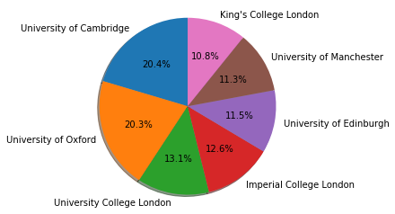

```python
import csv as csv
from tabulate import tabulate
from operator import itemgetter
import matplotlib.pyplot as plt

country = 'United Kingdom'
year = '2015'
max_rank = 100

readdata = csv.reader(open("cwurData.csv"))
alldata = []
for data in readdata:
    alldata.append(data)

title = alldata[0]
#print(title)
countrydata = alldata[1:]
record = [(itemgetter(0,1,3,12)(record)) for record in countrydata if record[2] == country and record[-1] == year and int(record[0]) <= max_rank]
print('\n\n', country, 'Top Universities (<',max_rank,') (',year,')\n')
print(tabulate(record,headers=(itemgetter(0,1,3,12)(alldata[0]))))

print('\n\n', country, 'Top Universities Based on',title[12].title())
# Pie chart, where the slices will be ordered and plotted counter-clockwise:
labels = [record[1] for record in countrydata if record[2] == country and record[-1] == year and int(record[0]) <= max_rank]
sizes = [record[12] for record in countrydata if record[2] == country and record[-1] == year and int(record[0]) <= max_rank]
slices = [0] * len(sizes)
explode = (slices)
fig1, ax1 = plt.subplots()
ax1.pie(sizes, explode=explode, labels=labels, autopct='%1.1f%%',
        shadow=True, startangle=90)
ax1.axis('equal')
plt.show()
```

#### 37. Automatic Column Extraction from CSV

Change 'column_name' vlaue to 'citations', 'score','world_rank' etc to see a different table

```python
import csv as csv
from tabulate import tabulate
from operator import itemgetter
import matplotlib.pyplot as plt

country = 'Germany'
year = '2015'
max_rank = 100
column_name = 'score'

readdata = csv.reader(open("cwurData.csv"))
alldata = []
for data in readdata:
    alldata.append(data)

column_title = dict([(v,k) for k, v in enumerate(alldata[0])])
column = column_title[column_name]

countrydata = alldata[1:]
record = [(data[0],data[1],data[3],data[column]) for data in countrydata if data[2] == country and data[-1] == year and int(data[0]) <= max_rank]
print('\n\n', country, 'Top Universities (<',max_rank,') (',year,')\n')
print(tabulate(record,headers=(itemgetter(0,1,3,column)(alldata[0]))))
```

```
 Germany Top Universities (< 100 ) ( 2015 )

  world_rank  institution                               national_rank    score
------------  --------------------------------------  ---------------  -------
          76  Ruprecht Karl University of Heidelberg                1    52.32
          79  Ludwig Maximilian University of Munich                2    52.16
```

#### 38. Defultdict() - Map empty dictionary entries to 0 or key

```python
from collections import defaultdict
pos = defaultdict(lambda: 'UNK')
sentence = 'this is a test'
pos['this'] = 'DT'
pos['test'] = ['NOUN','VERB']
for word in sentence.split():
    print(word, pos[word])
```

```
this DT
is UNK
a UNK
test ['NOUN', 'VERB']
```

#### 39. Cleaning Punctuations from a String

```python
sentence = 'This, is a list! full of . , punctions:'
cleaned  = "".join(c for c in sentence if c not in ('!',':','\'','"','`',',','.'))
print(cleaned)
```

```
This is a list full of   punctions
```

#### 40. Tag all sentences in corpus and taking Ngram, Bigram, Trigram, etc

```python
import nltk
from nltk import word_tokenize
from nltk.util import ngrams
from collections import Counter
import string
import re

corpus = nltk.corpus.CategorizedPlaintextCorpusReader('',r'.*\.txt',cat_pattern=r'(\w+)/*')
sents = corpus.sents(categories=['news','general'])
word_tag_pairs = [nltk.pos_tag(sent) for sent in sents]
all_tags = [w for w in word_tag_pairs]

cleaned_sents = []
for sent in sents:
    cleaned = [c for c in sent if c not in ('!',':','\'','"','`',',')]
    cleaned_sent = nltk.pos_tag(cleaned)
    cleaned_sents.append(cleaned_sent)

words = []
for entry in cleaned_sents:
    for word in entry:
        pattern = word[0],'/',word[1]
        words.append(pattern)

text = []
for tagged_word in words:
    tagged = ''.join(tagged_word)
    text.append(tagged)

tagged_text = ' '.join(text)
#print(tagged_text)


token = nltk.word_tokenize(tagged_text)
bigrams = ngrams(token,2)
trigrams = ngrams(token,3)
fourgrams = ngrams(token,4)
fivegrams = ngrams(token,5)


a = Counter(fourgrams)
freqdist = nltk.FreqDist(a)
b = freqdist.most_common(50)
for i in b:
    print(i)
```

#### 41. TRAIN corpus chunk + Search Chunk in Sentence

```python
import nltk
from tabulate import tabulate
from operator import itemgetter
import matplotlib.pyplot as plt
from nltk.util import ngrams
from collections import Counter

corpus = nltk.corpus.CategorizedPlaintextCorpusReader('',r'.*\.txt',cat_pattern=r'(\w+)/*')
sents = corpus.sents(categories=['news','general'])
word_tag_pairs = [nltk.pos_tag(sent) for sent in sents]
all_tags = [w for w in word_tag_pairs]

cleaned_sents = []
for sent in sents:
    cleaned = [c for c in sent if c not in ('!',':','\'','"','`',',')]
    cleaned_sent = nltk.pos_tag(cleaned)
    cleaned_sents.append(cleaned_sent)

words = []
for entry in cleaned_sents:
    for word in entry:
        pattern = word[0],'/',word[1]
        words.append(pattern)

text = []
for tagged_word in words:
    tagged = ''.join(tagged_word)
    text.append(tagged)

tagged_text = ' '.join(text)
#print(tagged_text)


token = nltk.word_tokenize(tagged_text)
bigrams = ngrams(token,2)
trigrams = ngrams(token,3)
fourgrams = ngrams(token,4)
fivegrams = ngrams(token,5)


fourgram_bundle = Counter(fourgrams)
freqdist = nltk.FreqDist(fourgram_bundle)
bundles = freqdist.most_common(100)

entries = [a for a in bundles]
#print(tabulate(entries))


### END OF TRAINING

sentence = 'It has negative impact on us.'
tagged_sentence = nltk.pos_tag(sentence.split())

sentence_words = []
for word in tagged_sentence:
    pattern = word[0],'/',word[1]
    sentence_words.append(pattern)

tagged_sentence = []
for tagged_word in sentence_words:
    tagged = ''.join(tagged_word)
    tagged_sentence.append(tagged)

#final_tagged_sent = ' '.join(tagged_sentence)
#print(tagged_sentence)

sentence_fourgrams = ngrams(tagged_sentence,4)
for x in sentence_fourgrams:
    for entry in entries:
        if entry[0] == x:
            print(entry)
```

#### 42. Classifier with Ngram as the featureset

```python
import nltk
from nltk import ngrams
import random

corpus = nltk.corpus.CategorizedPlaintextCorpusReader('', r'.*\.txt', cat_pattern=r'(\w+)/*')
documents = [(list(corpus.words(fileid)), category)
              for category in corpus.categories()
              for fileid in corpus.fileids(category)]

#Corpus sentences ngram
sents = corpus.sents()

stop_words = ['i', 'me', 'my', 'myself', 'we', 'our', 'ours', 'ourselves', 'you', 'your', 'yours', 'yourself', 'yourselves', 'he', 'him', 'his', 'himself', 'she', 'her', 'hers', 'herself', 'it', 'its', 'itself', 'they', 'them', 'their', 'theirs', 'themselves', 'what', 'which', 'who', 'whom', 'this', 'that', 'these', 'those', 'am', 'is', 'are', 'was', 'were', 'be', 'been', 'being', 'have', 'has', 'had', 'having', 'do', 'does', 'did', 'doing', 'a', 'an', 'the', 'and', 'but', 'if', 'or', 'because', 'as', 'until', 'while', 'of', 'at', 'by', 'for', 'with', 'about', 'against', 'between', 'into', 'through', 'during', 'before', 'after', 'above', 'below', 'to', 'from', 'up', 'down', 'in', 'out', 'on', 'off', 'over', 'under', 'again', 'further', 'then', 'once', 'here', 'there', 'when', 'where', 'why', 'how', 'all', 'any', 'both', 'each', 'few', 'more', 'most', 'other', 'some', 'such', 'no', 'nor', 'not', 'only', 'own', 'same', 'so', 'than', 'too', 'very', 's', 't', 'can', 'will', 'just', 'don', 'should', 'now', 'd', 'll', 'm', 'o', 're', 've', 'y', 'ain', 'aren', 'couldn', 'didn', 'doesn', 'hadn', 'hasn', 'haven', 'isn', 'ma', 'mightn', 'mustn', 'needn', 'shan', 'shouldn', 'wasn', 'weren', 'won', 'wouldn', '.', ',', '"', "'", '?', '!', ':', ';', '(', ')', '[', ']', '{', '}']

gramslist= []
n = 1
for sent in sents:
    sent = [x for x in sent if x not in stop_words]
    fourgrams = ngrams(sent, n)
    for grams in fourgrams:
        gramslist.append(grams)

def document_features(document):
    document_words = set(document)
    features = {}
    for word in gramslist:
        features['contains({})'.format(word)] = (word in document_words)
    return features

random.shuffle(documents)
featuresets = [(document_features(d), c) for (d,c) in documents]
train_set, test_set = featuresets[102:], featuresets[:102]
classifier = nltk.NaiveBayesClassifier.train(train_set)
print(nltk.classify.accuracy(classifier, test_set))
print(classifier.show_most_informative_features(10))
```